# Impacto de la vida amorosa en el ámbito académico de los alumnos de UTEC en el periodo 2022-2

# **Introducción**

## Relevancia

Una de las funciones importantes del estudiante de UTEC es velar por su buen desempeño académico en la universidad, el presente estudio puede complementar información si su vida amorosa está siendo un factor negativo que influencia en su rendimiento académico en el periodo 2022-2.

## Objetivos

### General

- Identificar si una relación sentimental afecta en el desempeño académico del estudiante de UTEC durante el periodo 2022-2.

### Específico

- Identificar si el rendimiento académico del estudiante resulta perjudicial como resultado de estar en una relación sentimental.
- Analizar si la mayoría de los estudiantes piensan que estar en una relación amorosa puede contribuir a descuidar los estudios.
- Analizar si los estudiantes logran administrar sus tiempos entre la universidad y su relación amorosa.
- Identificar qué rango de edad de estudiantes se encuentran en una relación amorosa.
- Evaluar la probabilidades empíricas de los eventos atómicos en las variables “Nrelaciones” y “RAcademicoAfectado” durante el período 2022-2 en una muestra de 204.
- Evaluar la probabilidades condicional entre las variables “Nrelaciones” y “Edad” y determinar la dependencia e independencia en los eventos planteados.
- Estudiar la variable discreta “Desconcentracion”, así como presentar su distribución geométrica y sus parámetros.
- Estudiar la variable continua “Promedio” así como también evaluar la prueba de distribución a los datos cuantitativos continuos.

## Contexto

Con este estudio buscamos analizar si estar en una relación sentimental afectan al desempeño académico del estudiante de UTEC en el periodo 2022-2, estudiando algunas variables así como realizando su análisis descriptivo y probabilístico, aplicando conocimientos básicos de Rstudio.

El tamaño de nuestra base de datos es de 204 encuestados, número resultante después de la limpieza de datos.

### 1) Numéricas

| **Variable** | **Tipo de variable** | **Restricciones** |
| --- | --- | --- |
| Edad | Discreta | Rango [16 - 40] |
| Nrelaciones | Discreta | Rango [1 - 10] |
| HEstudio | Continua | Rango [0 -23] |
| HPareja | Continua | Rango [0 - 23] |
| Promedio | Continua | Rango [1 - 20] |

### 2) Categóricas

| **Variable** | **Tipo de variable** | **Restricciones** |
| --- | --- | --- |
| Genero | Nominal | Tres opciones (femenino, masculino y no binario) |
| Carrera | Nominal | Toma valores del conjunto de carreras ofrecidas por UTEC. |
| Ciclo | Ordinal | Rango [2-10] |
| Relacion | Nominal | Limitado: “si o no” |
| MismaUniversidad | Nominal | Limitado: “si o no” |
| RAcademicoAfectado | Nominal | Limitado: “si o no” |
| INegativoMotivacion | Nominal | Limitado: “si o no” |
| Desafios | Nominal | Opciones a escoger: 4 |
| FormasDeApoyo | Nominal | Opciones a escoger: 3 |
| VidaAmorosa | Ordinal | Entero positivo [0 - 10] |
| VidaAcademica | Ordinal | Entero positivo [0 - 10] |
| RelacionVidaAmorosaYAcadémica | Ordinal | Entero positivo [0 - 10] |
| AdministrarTiempo | Nominal | Limitada: “si o no” |
| FaltaClases | Nominal | Limitado: “si o no” |
| RelacionYUniversidad | Nominal | Respuesta binaria (sí considero y no considero) |
| DiscusionesAfectaConcentracion | Nominal | Respuesta binaria (sí afecta y no afecta) |
| Desconcentracion | Nominal | Limitada: “si o no” |
| RupturaAfectaExamenes | Nominal | Limitada: “si o no” |
| FormasAfectaRendimientoAcademico | Nominal | Opciones a escoger: 6 |

# **Análisis descriptivo**

## Variables aleatorias discretas:

Estudiar las variables presentando evidencia numérica y gráfica.

### “FaltaClases”

- Variable: FaltaClases
- Distribución: Binomial X~B(n,p)
- Elaboramos una tabla de función de probabilidad:

```
##
##  Tabla 1: Probabilidades de la variable FaltaClases
```

```
##
##        No        Sí
## 0.2941176 0.7058824
```

- Construir la variable aleatoria:

Estudiantes que faltan a clases por salir con su pareja

X: número de estudiantes que faltan a clases por salir con su pareja, un estudio que se llevo a cabo en UTEC con 204 personas.

- Definir parámetros:

X~B(n,p)

donde, {P => P(E), donde el éxito es definido como seleccionar a estudiantes que faltan a clases por salir con su pareja; n => tamaño de la muestra(204)}

Hallar P:

$$\:P\left(E\right)=\frac{\:\left(casos\:a\:favor\right)}{\left(casos\:totales\right)}\:=0.7058824$$
Graficamos la función de probabilidad binomial:

[figure not shown]

- Determinación de los parámetros:
- Valor esperado:
  $$E\left(X\right)\:=\:n\cdot p$$
  $$E\left(X\right)\:=(204)\cdot (0.7058824)\:=
  144$$

El valor esperado es 144; promedio ponderado de los valores que toma la variable aleatoria “FaltaClases”

- Varianza:

$$V\left(X\right)=\:n\cdot p\cdot
q$$
Donde: (q=1-p)

$$V\left(X\right)=\:204\cdot
0.7058824\cdot \left(1-0.7058824\right)\:= 42.35294$$
Entonces, la varianza de la variable “FaltaClases” es de 42.35294, que representa la desviación respecto a la media de la distribución.

El experimento consiste determinar al numero de estudiantes que faltan a clases por salir con su pareja en una muestra n.

- Construir un ejemplo:

En un salón de clases de estadística de un total de 45 alumnos se desea determinar la probabilidad de que más del 50% de ellos no hayan faltado a clases por salir con su pareja.

Y: Número de estudiantes que faltan a clases por salir con su pareja en una muestra 45.

Y~B(n=45,p=0.7058824)

G: Número de estudiantes que no faltan a clases por salir con su pareja en una muestra de 45.

G~B(n=45,p=0.2941176)

P(G>45/2) = P(G>22.5) = P(Y≤22.5)

```r
pbinom(22.5,45,0.7058824)
```

```
## [1] 0.001819911
```

[figure not shown]

Entonces la probabilidad de que en un salón de 45 estudiantes el 50% no falte a clases es de: 0.001819911

### “Desconcentracion”

- Definir que distribución usaremos: Geometrica
- Construir variable que usaremos: “Desconcentracion”
- Elaboramos una tabla de función de probabilidad:

```
##
##  Tabla 2: Probabilidades de la variable: Desconcentracion
```

```
##
##         No         Sí
## 0.03921569 0.96078431
```

- Construir la variable aleatoria:

El experimento consiste en encuestar a estudiantes hasta encontrar al primero que si se desconcentra por esperar o contestar mensajes de su pareja

X: Número de estudiantes encuestados hasta encontrar al primero que se desconcentra por esperar o contestar mensajes de su pareja

- Definir parámetros:

X ~ G(p) ; donde {p => p(e), donde éxito es definido como encontar el primer caso de un estudiante que se distrae en clases por responder mensajes de su pareja}

Hallar P:

$$\:P\left(E\right)=\frac{\:\left(casos\:a\:favor\right)}{\left(casos\:totales\right)}\:=0.96078431$$
Graficamos la función de probabilidad geometrica:

[figure not shown]

- Determinación de los parámetros:

Valor esperado:

$$E\left(X\right)\:=\:\frac{1}{p}$$
$$E\left(X\right)\:=\:\frac{1}{0.96078431}\:=\:1.040816$$

Varianza:

$$V\left(X\right)=\frac{1-p}{p^2}$$

$$V\left(X\right)=0.0424823$$

- Construir un ejemplo:

Estimando la probabilidad de éxito; Si yo aplico una nueva encuesta, determinar que tan probable es que yo tenga que encuestar solo a 5 estudiantes para encontrar al primero que no se distrae en el móvil por hablar con su pareja en clase.

Y: Número de estudiantes encuestados necesarios hasta encontrar al primero que no se desconcentran por esperar o contestar mensajes de su pareja.

Y~G(p=0.03921569)

Entonces se pide lo siguiente P(Y=5)

```r
dgeom(5,0.03921569)
```

```
## [1] 0.03210623
```

Graficamos la función de probabilidad geometrica:

[figure not shown]

Entonces la probabilidad de encuestar solo 5 estudiantes hasta encontrar el primer alumno que no se desconcentre en el celular por responder mensajes de su pareja es de: 0.03210623

## Variables aleatorias continuas:

### “Promedio”

- Variable continua: “Promedio”
- Distribución:Gamma

Encontrar el rango mínimo y máximo de la variables “Promedio”:

```r
range(B1$Promedio, na.rm = T)
```

```
## [1] 10.5 18.8
```

Histograma de la variable “Promedio”:

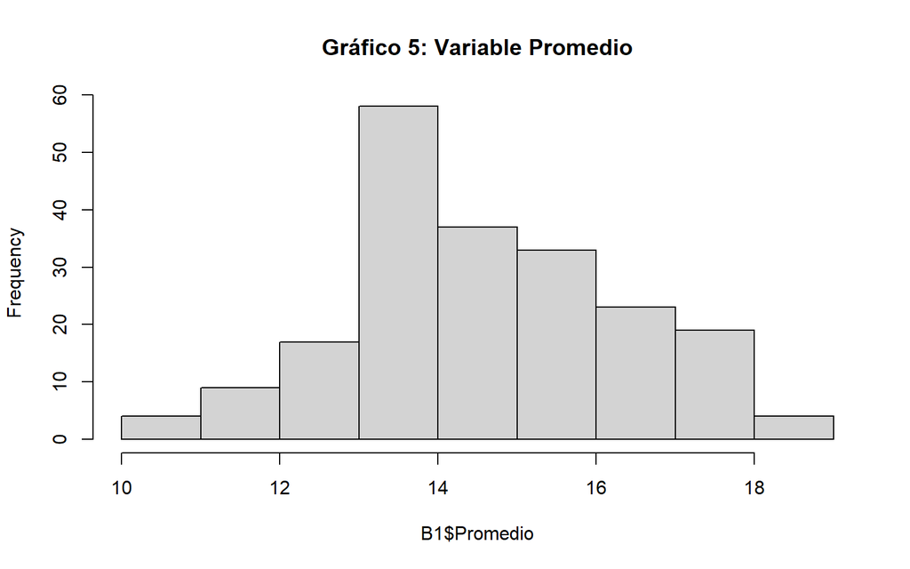

Fit.cont para la variable: Promedio

```
##
## Begin fitting distributions ---------------------------------------
```

```
## * fitting normal distribution ... OK
```

```
## * fitting Cauchy  distribution ... OK
```

```
## * fitting logistic distribution ... OK
```

```
## * fitting beta distribution ... failed
```

```
## * fitting exponential distribution ... OK
```

```
## * fitting chi-square distribution ... OK
```

```
## * fitting uniform distribution ... OK
```

```
## * fitting gamma distribution ... OK
```

```
## * fitting lognormal distribution ... OK
```

```
## * fitting Weibull distribution ... OK
```

```
## * fitting F-distribution ... OK
```

```
## * fitting Student's t-distribution ... OK
```

```
## * fitting Gompertz distribution ... failed
```

```
## * fitting triangular distribution ... failed
```

```
## End fitting distributions -----------------------------------------
```

```
##                 logL     AIC     BIC Chisq(value) Chisq(p) AD(value)    H(AD)
## Normal       -402.88  809.76  816.39        63.90        0      1.28 rejected
## Cauchy       -443.88  891.77  898.41        98.88        0      4.54 rejected
## Logistic     -406.77  817.54  824.17        65.02        0      1.46 rejected
## Exponential  -753.28 1508.56 1511.87      1439.29        0     73.24 rejected
## Chi-square   -541.52 1085.04 1088.36       376.16        0     32.42     NULL
## Uniform         NULL    NULL    NULL        82.96        0       Inf     NULL
## Gamma        -402.98  809.95  816.59        56.92        0      1.07 rejected
## Lognormal    -403.67  811.35  817.98        54.25        0      1.06 rejected
## Weibull      -409.34  822.67  829.31        93.91        0      2.63 rejected
## F           -1009.63 2023.25 2029.89      5525.50        0    115.74     NULL
## Student     -1172.43 2346.86 2350.18     12536.24        0    206.67     NULL
##             KS(value)        H(KS)
## Normal           0.10     rejected
## Cauchy           0.11     rejected
## Logistic         0.10     rejected
## Exponential      0.52     rejected
## Chi-square       0.28     rejected
## Uniform          0.14     rejected
## Gamma            0.09 not rejected
## Lognormal        0.09 not rejected
## Weibull          0.11     rejected
## F                0.68     rejected
## Student          0.83     rejected
```

```
##
## Chosen continuous distribution is: NA
## Fitted parameters are:
## [1] NA
```

$$X ~ Gamma (α,β)$$
Los parámetros:
$$1/β : 4.806986$$

$$α : 70.994705$$
Fitted parameters are: shape rate 70.994705 4.806986

Parámetros teóricos

```
## [1] 14.76912
```

```
## [1] 1.747899
```

- La media de Promedio : 14.76912
- La desviación estándar es : 1.747899

Densidad de la variable: Promedio

```
##
## Call:
##  density.default(x = B1$Promedio)
##
## Data: B1$Promedio (204 obs.);    Bandwidth 'bw' = 0.543
##
##        x                y
##  Min.   : 8.871   Min.   :5.051e-05
##  1st Qu.:11.760   1st Qu.:1.270e-02
##  Median :14.650   Median :6.715e-02
##  Mean   :14.650   Mean   :8.643e-02
##  3rd Qu.:17.540   3rd Qu.:1.469e-01
##  Max.   :20.429   Max.   :2.430e-01
```

Distribución Gamma de la variable: “Promedio”

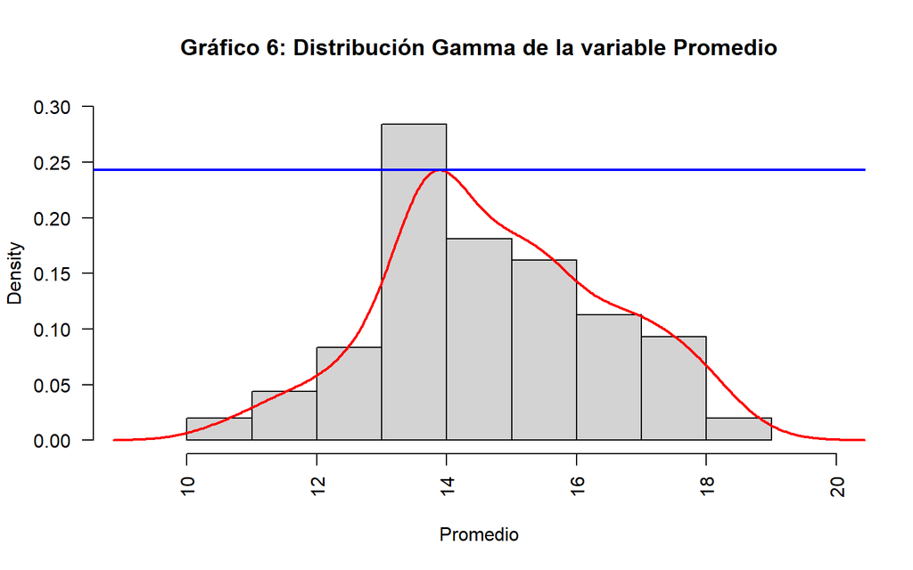

Caso 1: Sabemos que la variable “Promedio” tiene una distribución gamma; determinar la probabilidad de que el promedio durante el ciclo 2022-2 de un estudiante elegido al azar sea mayor o igual a 15 y menor a 20

```r
pgamma(20, 70.994705, 4.806986 ) - pgamma(15, 70.994705, 4.806986 )
```

```
## [1] 0.4290976
```

Gráfica de densidad de probabilidad:

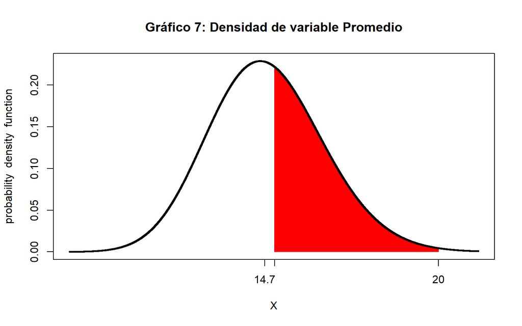

A partir de ello se puede observar que en caso de elegirse a un alumno al azar que se encuentra en una relación amorosa es menos probable que tengan un promedio mayor o igual a 15.

### “HEstudio”

- Variable continua: “HEstudio”
- Distribucion:Uniforme

Fit.cont para la variable: “HEstudio”

```r
fit.cont(B1$HEstudio)
```

```
##
## Begin fitting distributions ---------------------------------------
```

```
## * fitting normal distribution ... OK
```

```
## * fitting Cauchy  distribution ... OK
```

```
## * fitting logistic distribution ... OK
```

```
## * fitting beta distribution ... failed
```

```
## * fitting exponential distribution ... OK
```

```
## * fitting chi-square distribution ... OK
```

```
## * fitting uniform distribution ... OK
```

```
## * fitting gamma distribution ... OK
```

```
## * fitting lognormal distribution ... OK
```

```
## * fitting Weibull distribution ... OK
```

```
## * fitting F-distribution ... OK
```

```
## * fitting Student's t-distribution ... OK
```

```
## * fitting Gompertz distribution ... OK
```

```
## * fitting triangular distribution ... failed
```

```
## End fitting distributions -----------------------------------------
```

```
##                logL     AIC     BIC Chisq(value) Chisq(p) AD(value)    H(AD)
## Normal      -401.44  806.88  813.51       194.80        0      3.39 rejected
## Cauchy       -453.6   911.2  917.84       300.63        0      6.01 rejected
## Logistic    -408.74  821.49  828.12       202.99        0      3.53 rejected
## Exponential -477.68  957.36  960.68       522.83        0     26.63 rejected
## Chi-square  -422.32  846.64  849.96       306.41        0      7.55     NULL
## Uniform        NULL    NULL    NULL       207.96        0       Inf     NULL
## Gamma       -398.19  800.39  807.03       246.20        0      3.75 rejected
## Lognormal   -405.71  815.42  822.06       302.62        0      5.24 rejected
## Weibull     -394.42  792.84  799.48       207.06        0      3.03 rejected
## F           -567.48 1138.95 1145.59      1191.30        0     79.43     NULL
## Student     -751.27 1504.55 1507.86      3140.50        0    198.46     NULL
## Gompertz    -400.03  804.07   810.7       193.31        0      3.04     NULL
##             KS(value)    H(KS)
## Normal           0.13 rejected
## Cauchy           0.15 rejected
## Logistic         0.12 rejected
## Exponential      0.31 rejected
## Chi-square       0.15 rejected
## Uniform          0.11 rejected
## Gamma            0.11 rejected
## Lognormal        0.14 rejected
## Weibull          0.12 rejected
## F                0.51 rejected
## Student          0.75 rejected
## Gompertz         0.12 rejected
```

```
##
## Chosen continuous distribution is: NA
## Fitted parameters are:
## [1] NA
```

Según el análisis de distribuciones realizado Kolmogorov Smirnov y Anderson no se ajusta a ninguna distribución nuestros datos.

Ante esto hicimos un filtro para poder hallar una distribución continua de la variable Ciclo: Seleccionaremos solo estudiantes de 2° ciclo del periodo 2022-2

```r
G2 <- subset(B1,Ciclo == 2)
```

```r
fit.cont(G2$HEstudio)
```

```
##
## Begin fitting distributions ---------------------------------------
```

```
## * fitting normal distribution ... OK
```

```
## * fitting Cauchy  distribution ... OK
```

```
## * fitting logistic distribution ... OK
```

```
## * fitting beta distribution ... failed
```

```
## * fitting exponential distribution ... OK
```

```
## * fitting chi-square distribution ... OK
```

```
## * fitting uniform distribution ... OK
```

```
## * fitting gamma distribution ... OK
```

```
## * fitting lognormal distribution ... OK
```

```
## * fitting Weibull distribution ... OK
```

```
## * fitting F-distribution ... OK
```

```
## * fitting Student's t-distribution ... OK
```

```
## * fitting Gompertz distribution ... OK
```

```
## * fitting triangular distribution ... failed
```

```
## End fitting distributions -----------------------------------------
```

```
##                logL    AIC    BIC Chisq(value) Chisq(p) AD(value)    H(AD)
## Normal      -143.08 290.17 294.72        84.22        0      1.97 rejected
## Cauchy       -159.8 323.61 328.16        71.07        0      3.27 rejected
## Logistic    -145.18 294.36 298.91        78.08        0      1.91 rejected
## Exponential -164.63 331.27 333.55       175.90        0      8.78 rejected
## Chi-square  -146.78 295.55 297.83       114.19        0      2.75     NULL
## Uniform        NULL   NULL   NULL       109.42        0       Inf     NULL
## Gamma       -138.45 280.91 285.46        84.18        0      1.52 rejected
## Lognormal   -139.48 282.95 287.51        92.11        0      1.75 rejected
## Weibull     -138.91 281.82 286.37        83.45        0      1.48 rejected
## F           -192.51 389.03 393.58       323.36        0     26.99     NULL
## Student     -257.92 517.83 520.11       902.18        0     69.81     NULL
## Gompertz    -142.95 289.91 294.46        98.74        0      1.78     NULL
##             KS(value)        H(KS)
## Normal           0.19     rejected
## Cauchy           0.17     rejected
## Logistic         0.17     rejected
## Exponential      0.33     rejected
## Chi-square       0.16     rejected
## Uniform          0.15 not rejected
## Gamma            0.16 not rejected
## Lognormal        0.13 not rejected
## Weibull          0.17     rejected
## F                0.53     rejected
## Student          0.76     rejected
## Gompertz         0.14 not rejected
```

```
##
## Chosen continuous distribution is: NA
## Fitted parameters are:
## [1] NA
```

Distribución uniforme:

$$X ∼ U(a, b)$$
Los parámetros:

$$a: 0.5628135$$

$$b : 6.6780198$$
Fitted parameters are: min max 0.5628135 6.6780198

Histograma de la variable: “HEstudio”

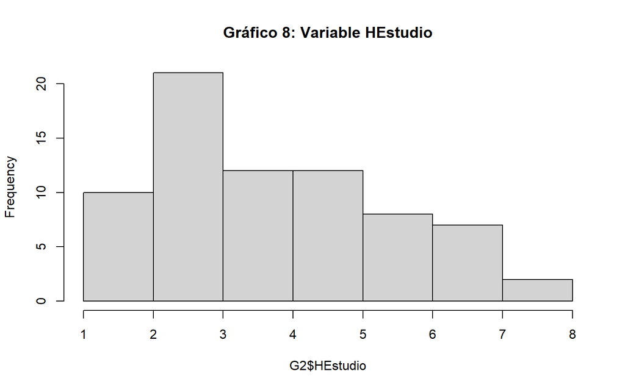

```r
hist(G2$HEstudio, main="Gráfico 8: Variable HEstudio")
```

### Parámetros teóricos

```
## [1] 3.620417
```

```
## [1] 1.777696
```

- La media de HEstudio : 3.620417
- La desviación estándar es : 1.777696

Densidad de la variable: HEstudio

```r
density(G2$HEstudio)
```

```
##
## Call:
##  density.default(x = G2$HEstudio)
##
## Data: G2$HEstudio (72 obs.); Bandwidth 'bw' = 0.6282
##
##        x                 y
##  Min.   :-0.6846   Min.   :0.0001066
##  1st Qu.: 1.9077   1st Qu.:0.0214713
##  Median : 4.5000   Median :0.0862373
##  Mean   : 4.5000   Mean   :0.0963293
##  3rd Qu.: 7.0923   3rd Qu.:0.1563082
##  Max.   : 9.6846   Max.   :0.2310777
```

Gráfica de densidad:

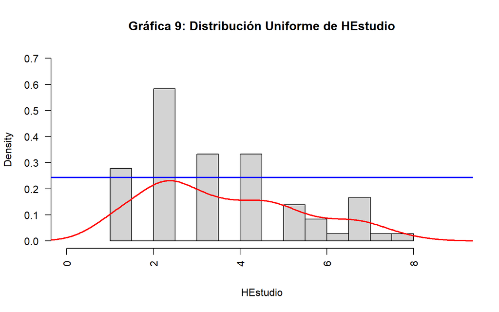

Caso: Sabemos que la variable “HEstudio” tiene una distribución uniforme, determinar la probabilidad de que las horas de estudio durante el ciclo 2022-2 de un estudiante de segundo ciclo elegido al azar sea mayor a 2 y menor a 4 horas.

X: Horas de estudio de un estudiante mayor a 2 y menor a 4 horas

```r
punif(4,0.5628135,6.6780198) - punif(2,0.5628135,6.6780198)
```

```
## [1] 0.3270536
```

Gráfica de densidad de probabilidad:

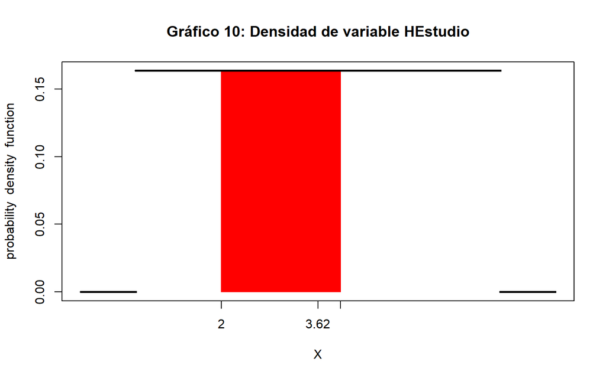

- Entonces la probabilidad de que las horas de estudio durante el ciclo 2022-2 de un estudiante de segundo ciclo elegido al azar sea mayor a 2 y menor a 4 : 0.3270536
- Y de la gráfica de densidad de probabilidad podemos decir que la probabilidad de 2 a 4 horas se mantiene uniforme.

# **Análisis probabilísticos**

## Probabilidad empíricas:

Ahora realizaremos el análisis de nuestras variables más importantes en términos de las probabilidades de los distintos eventos que estas logran representar.

### Análisis de la variable `Nrelaciones` y `RAcademicoAfectado`

#### Nrelaciones

```
##
##  Tabla 3: Número de relaciones amorosas
```

```
##
##      1      2      3      4      5      6      7      8      9
## 0.2843 0.1814 0.2353 0.1716 0.0833 0.0294 0.0049 0.0049 0.0049
```

#### Define los eventos:

-El evento atómico asociado al estudiante que haya tenido 1 relación amorosa: “Seleccionar un estudiante que haya tenido 1 relación en una muestra de tamaño 204”.

-El evento atómico asociado al estudiante que haya tenido 2 relaciones amorosas: “Seleccionar un estudiante que haya tenido 2 relaciones en una muestra de tamaño 204”.

-El evento atómico asociado al estudiante que haya tenido 3 relaciones amorosas: “Seleccionar un estudiante que haya tenido 3 relaciones en una muestra de tamaño 204”.

-El evento atómico asociado al estudiante que haya tenido 4 relaciones amorosas: “Seleccionar un estudiante que haya tenido 4 relaciones en una muestra de tamaño 204”.

-El evento atómico asociado al estudiante que haya tenido 5 relaciones amorosas: “Seleccionar un estudiante que haya tenido 5 relaciones en una muestra de tamaño 204”.

-El evento atómico asociado al estudiante que haya tenido 6 relaciones amorosas: “Seleccionar un estudiante que haya tenido 6 relaciones en una muestra de tamaño 204”.

-El evento atómico asociado al estudiante que haya tenido 7 relaciones amorosas: “Seleccionar un estudiante que haya tenido 7 relaciones en una muestra de tamaño 204”.

-El evento atómico asociado al estudiante que haya tenido 8 relaciones amorosas: “Seleccionar un estudiante que haya tenido 8 relaciones en una muestra de tamaño 204”.

-El evento atómico asociado al estudiante que haya tenido 9 relaciones amorosa: “Seleccionar un estudiante que haya tenido 9 relaciones en una muestra de tamaño 204”.

### RAcadémicoAfectado

```
##
##  Tabla 4: Considera el estudiante su rendimiento académico afectado
```

```
##
##     No     Sí
## 0.2353 0.7647
```

#### Define los eventos:

- El evento atómico asociado a no les afecta académicamente sería: “Seleccionar una persona que no le afecta académicamente estar en una relación en una muestra de tamaño 204”.
- El evento atómico asociado a si les afecta académicamente sería: “Seleccionar una persona que si le afecta académicamente estar en una relación en una muestra de tamaño 204”.

### Calcular la función probabilidad de los eventos atómicos:

1. ¿Cuál es la probabilidad de que un estudiante considere que sí le afecta estar en una relación amorosa durante el ciclo académico 2022-2?
- X: estudiante que le afecta estar en una relación académica
- Rx={No, Sí}
- P(X=Sí)= 0.7647
2. ¿Cuál es la probabilidad de que un estudiante considere que no le afecta estar en una relación amorosa durante el ciclo académico 2022-2?
- X: estudiante que no le afecta estar en una relación académica
- Rx={No, Sí}
- P(X=No)= 0.2353

#### Formas

```
##
##  Tabla 5: Apoyo que desee el estudiante
```

```
##
##      C    C-R    C-T  C-T-R      R      T    T-R
## 0.2157 0.0245 0.1324 0.0882 0.2598 0.2598 0.0196
```

- C: Consejería o terapia de pareja
- C-R: Consejería o terapia de pareja, Recursos en línea (por ejemplo, artículos, videos, podcasts, etc.)
- C-T: Consejería o terapia de pareja - Talleres o grupos de discusión sobre relaciones saludables
- C-T-R: Consejería o terapia de pareja - Talleres o grupos de discusión sobre relaciones saludables - Recursos en línea (por ejemplo, artículos, videos, podcasts, etc.)
- R: Recursos en línea (por ejemplo, artículos, videos, podcasts, etc.)
- T: Talleres o grupos de discusión sobre relaciones saludables
- T-R: Talleres o grupos de discusión sobre relaciones saludables, Recursos en línea (por ejemplo, artículos, videos, podcasts, etc.)

### Define los eventos:

- El evento atómico asociado a alumnos que desean consejerías o terapia de pareja sería: “Seleccionar 1 persona que desea consejerías o terapia de pareja en una muestra de tamaño 204”.
- El evento atómico asociado a alumnos que desean Consejería o terapia de pareja, Recursos en línea (por ejemplo, artículos, videos, podcasts, etc.) sería: “Seleccionar 1 persona que desea Consejería o terapia de pareja, Recursos en línea (por ejemplo, artículos, videos, podcasts, etc.) en una muestra de tamaño 204”.
- El evento atómico asociado a alumnos que desean Consejería o terapia de pareja, Talleres o grupos de discusión sobre relaciones saludables sería: “Seleccionar 1 persona que desea Consejería o terapia de pareja en una muestra de tamaño 204”.
- El evento atómico asociado a alumnos que desean Consejería o terapia de pareja, Talleres o grupos de discusión sobre relaciones saludables, Recursos en línea (por ejemplo, artículos, videos, podcasts, etc.) sería: “Seleccionar 1 persona que desea Consejería o terapia de pareja, Talleres o grupos de discusión sobre relaciones saludables, Recursos en línea (por ejemplo, artículos, videos, podcasts, etc.) en una muestra de tamaño 204”.
- El evento atómico asociado a alumnos que desean Recursos en línea (por ejemplo, artículos, videos, podcasts, etc.) sería: “Seleccionar una persona que desea Recursos en línea (por ejemplo, artículos, videos, podcasts, etc.) en una muestra de tamaño 204”.
- El evento atómico asociado a alumnos que desean Talleres o grupos de discusión sobre relaciones saludables sería: “Seleccionar una persona que desea Talleres o grupos de discusión sobre relaciones saludables en una muestra de tamaño 204”.
- El evento atómico asociado a alumnos que desean Talleres o grupos de discusión sobre relaciones saludables, Recursos en línea (por ejemplo, artículos, videos, podcasts, etc.) sería: “Seleccionar una persona que desea Talleres o grupos de discusión sobre relaciones saludables, Recursos en línea (por ejemplo, artículos, videos, podcasts, etc.) en una muestra de tamaño 204”.

### Calcular la función probabilidad:

1. ¿Cuál es la probabilidad de que un estudiante desee apoyo mediante “consejería o terapia de pareja” en el período 2022-2?
- X: formas de apoyo brindadas por la universidad
- Rx={C, C-R, C-T, C-T-R, R, T,T-R}
- P(X)= P(X=C)= 0.2157
2. ¿Cuál es la probabilidad de que un estudiante desee apoyo mediante “Recursos en línea (por ejemplo, artículos, videos, podcasts, etc.)” y “Talleres o grupos de discusión sobre relaciones saludables” en el período 2022-2?
- X: formas de apoyo brindadas por la universidad
- Rx={C, C-R, C-T, C-T-R, R, T, T-R }
- P(X)= P(X=R)+P(X=T)= 0.2598 + 0.2598 = 0.5196
3. ¿Cuál es la probabilidad de que un estudiante desee más de un tipo de apoyo en el período 2022-2?
- X: formas de apoyo brindadas por la universidad
- Rx={C, C-R, C-T, C-T-R, R, T, T-R}
- P(X)=P(X=C-R)+P(X=C-T)+P(X=C-T-R)+P(X=T-R) = 0.0245+0.1324+0.0882+0.0196 = 0.2647

## Probabilidad condicional:

#### Anáñisis de la variable “Nrelaciones” y “Edad

```r
titulo <- "Tabla 6: Número de relaciones de los estudiantes por edad"
cat("\n", titulo, "\n\n")
```

```
##
##  Tabla 6: Número de relaciones de los estudiantes por edad
```

```r
addmargins(table(B1$Nrelaciones,B1$Edad))
```

```
##
##        17  18  19  20  21  22  23  24 Sum
##   1     5  19  15  13   2   3   1   0  58
##   2     1  13  13   2   5   1   1   1  37
##   3     2  15   6  11   2   9   2   1  48
##   4     1   2   3   0   2  14  13   0  35
##   5     1   3   3   2   1   4   3   0  17
##   6     2   0   1   1   0   0   2   0   6
##   7     0   1   0   0   0   0   0   0   1
##   8     0   0   1   0   0   0   0   0   1
##   9     0   1   0   0   0   0   0   0   1
##   Sum  12  54  42  29  12  31  22   2 204
```

```r
titulo <- "Tabla 7: Intersección de los eventos"
cat("\n", titulo, "\n\n")
```

```
##
##  Tabla 7: Intersección de los eventos
```

```r
tabla<-rbind(c(6,89,95),c(6,103,109),c(12,192,204))
rownames(tabla)<-c("A","A'","total")
colnames(tabla)<-c("B","B'","total")
tabla
```

```
##        B  B' total
## A      6  89    95
## A'     6 103   109
## total 12 192   204
```

$$P(A \cap B)\:=
6/204\:=0.02941176$$

La probabilidad de A:
$$P(A)\:=95/204\:=0.4656863$$

La probabilidad de B:
$$P(B)\:=12/204\:=0.05882353$$

Multiplicar las probabilidades de A y B:
$$P\left(A\right)\cdot
P\left(B\right)\:=0.4656863\cdot 0.05882353\:=\:0.02739331$$

Calcular la dependencia o independencia:
$$P\left(A\:∩\:B\right)\:=\:P\left(A\right)\cdot
P\left(B\right)\:$$
$$0.02941176\:=\:0.02739331$$
Entonces comprobamos que las variables “Nralaciones” y “Edad” son dependientes debido al resultado obtenido

Probabilidad condicional

- P(A|B) = P(A n B) / P(B)
- P(A|B) = 0.02941176 / 0.05882353
- P(A|B) = 0.4999999

```
## [1] 0.4999999
```

Por otro lado, usando Bayes, se verifica entonces

- P(B|A) = P(A|B)P(B) / P(A)
- P(B|A) = 0.4999999* 0.05882353 / 0.4656863
- P(B|A) = 0.06315788

```
## [1] 0.06315788
```

#### Anáñisis de la variable “Nrelaciones” y “Carrera”

```r
titulo <- "Tabla 8: Número de relaciones de los estudiantes por carrera"
cat("\n", titulo, "\n\n")
```

```
##
##  Tabla 8: Número de relaciones de los estudiantes por carrera
```

```r
addmargins(table(B1$Nrelaciones,B1$Carrera))
```

```
##
##       Administración y Negocios Digitales Bioingeniería Ciencia de Datos
##   1                                     4             7                1
##   2                                     1             5                1
##   3                                     0             4                1
##   4                                     0             1                0
##   5                                     0             0                0
##   6                                     0             0                0
##   7                                     0             0                0
##   8                                     0             0                0
##   9                                     0             0                0
##   Sum                                   5            17                3
##
##       Ciencia de la Computación Ingeniería Ambiental Ingeniería Civil
##   1                           3                    4               13
```

[output cut: 33 more lines]

```r
titulo <- "Tabla 9: Intersección de los eventos"
cat("\n", titulo, "\n\n")
```

```
##
##  Tabla 9: Intersección de los eventos
```

```r
tabla<-rbind(c(10,51,61),c(25,118,143),c(35,169,204))
rownames(tabla)<-c("C","C'","total")
colnames(tabla)<-c("D","D'","total")
tabla
```

```
##        D  D' total
## C     10  51    61
## C'    25 118   143
## total 35 169   204
```

La probabilidad de C intersectado en D: P(C ∩ D)
$$P(C \cap D)\:= 10/204 = 0.04901961$$

Probabilidad de C:
$$P(C)\:=61/204 = 0.2990196$$
Probabilidad de D:
$$P(D)\:= 35/204 =
0.1715686$$
Multiplicar la probabilidad de C y D:

Función de condicional

- P(C|D) =P(C n D) /P(D)
- P(C|D) = 0.04901961 / 0.1715686
- P(C|D) = 0.2857143

```
## [1] 0.2857143
```

Por otro lado, usando Bayes, se verifica entonces

- P(D|C) = P(C|D)P(D) / P(C)
- P(D|C) = 0.2857143*0.1715686 / 0.2990196
- P(D|C) = 0.1639344

```
## [1] 0.1639344
```

#### Anáñisis de la variable “RAcademico” y “Genero”:

```r
titulo <- "Tabla 10: Rendimiento académico de los estudiantes por género"
cat("\n", titulo, "\n\n")
```

```
##
##  Tabla 10: Rendimiento académico de los estudiantes por género
```

```r
addmargins(table(B1$Genero,B1$RAcademicoAfectado))
```

```
##
##               No  Sí Sum
##   Femenino    25  69  94
##   Masculino   23  86 109
##   No binario   0   1   1
##   Sum         48 156 204
```

Definir eventos:

- Z: estudiantes de género masculino
- Z’: estudiantes que no son de género masculino
- Y: estudiantes afectados académicamente
- Y’: estudiantes no afectados académicamente

```r
titulo <- "Tabla 11: Intersección de los eventos"
cat("\n", titulo, "\n\n")
```

```
##
##  Tabla 11: Intersección de los eventos
```

```r
tabla<-rbind(c(86,23,109),c(70,25,95),c(156,48,204))
rownames(tabla)<-c("Z","Z'","total")
colnames(tabla)<-c("Y","Y'","total")
tabla
```

```
##         Y Y' total
## Z      86 23   109
## Z'     70 25    95
## total 156 48   204
```

Probabilidad de Z intersectado en Y: P(Z ∩ Y)
$$P(Z \cap Y)\:= 86/204 = 0.4215686$$
Probabilidad de Z:
$$P(Z)\:= 109/204 =
0.5343137$$
Probabilidad de Y:
$$P(Y)\:= 156/204 = 0.7647059$$
Multiplicando las probabilidades:

$$P(Z) \cdot P(Y) \:=0.5343137*0.7647059=
0.4085928$$

Probabilidad condicional

- P(Z|Y) = P(Z n Y) / P(Y)
- P(Z|Y) = 0.4215686 / 0.7647059
- P(Z|Y) = 0.551282

```
## [1] 0.551282
```

Por otro lado, usando Bayes, se verifica entonces

- P(Y|Z) = P(Z|Y)P(Y) / P(Z)
- P(Y|Z) = 0.551282*0.7647059 / 0.5343137
- P(Y|Z) = 0.7889908

```
## [1] 0.7889908
```

# **Conclusiones**

- Luego de evaluar las probabilidades empíricas de la variable “Nrelaciones” determinamos que hay una alta probabilidad de que los estudiantes hayan tenido más de 1 relación en el periodo 2022-2.
- Luego de evaluar las probabilidades condicionales de las variables “Edad” y “Nrelaciones” determinamos que son dependientes a través de la siguiente propiedad P(A|B)= P(A ∩ B)/P(B).
- Al estudiar la variable discreta “Desconcentracion” y realizar una distribución geometrica; analizamos un caso: la probabilidad de que tan probable es que al encuestar solo a 5 estudiantes para encontrar al primero que no se distrae en el móvil mientras está en clases: 0.03210623
- Al realizar el fitting continuous distributions de la variable continua “Promedio” se determinó que su distribución sería gamma según la prueba de bondad de ajuste de Kolmogorov-Smirnov.